# Spatial data visualization

Claire Meuter

2023-03-18

```r
knitr::opts_chunk$set(echo = TRUE, warning = FALSE, message = FALSE)
library(tidyverse) #always
library(here) #ease to read files in
library(sf) #sf packafe for shp file work
library(tmap) #interactive mapping
```

# Task 1 objectives and data

## Data

This homework uses data from California Department of Fish and Wildlife on oil spill incident data across California, as pulled from the OSPR Incident Tracking Database. As described on CA.gov: ” The OSPR Incident Tracking Database System project was initiated to provide OSPR with oil spill incident data for statistical evaluation and justification for program planning, drills and exercise training and development, legislative analysis, budget preparation, to inform and educate the public and analyze OSPRs overall spill preparedness and response performance.” The database defines an oil spill incident as “a discharge or threatened discharge of petroleum or other deleterious material into the waters of the state.”

**Data Citations:**

Lampinen, M. (2020, Jan. 31). Oil Spill Incident Tracking [ds394]. Calif. Dept. of Fish and Wildlife. Biogeographic Information and Observation System (BIOS). Retrieved March 18, 2020 from https://gis.data.ca.gov/datasets/7464e3d6f4924b50ad06e5a553d71086_0/explore?location=37.191046%2C-118.647988%2C6.47

California Counties. (2021, July 30). California Department of Forestry and Fire Protection. Retrieved March 18, 2020 from https://gis.data.ca.gov/datasets/CALFIRE-Forestry::california-counties-1/explore?location=37.084185%2C-119.270300%2C6.68

```r
# data exploration and cleaning
## read in the data
oil_spill <- read_csv(here("data","Oil_Spill_Incident_Tracking.csv"))  %>%
  janitor::clean_names() #cleaning up the column names
## Read in the counties data
ca_counties <- read_sf(here("data","ca_counties","CA_Counties_TIGER2016.shp")) %>%
  janitor::clean_names() %>%
  dplyr::select(county_name = name, land_area = aland)


#I want this data to be spatial, so I should convert it to a sf

oil_spill_sf <- st_as_sf(oil_spill, coords = c("x","y"), crs=st_crs(ca_counties))
#st_crs(oil_spill_sf)
#quick plot to see if things look okay
#plot(oil_spill_sf$geometry)
```

## Interactive Map

```r
# making my tmap
oil_map <- tm_shape(oil_spill_sf) +
  tm_dots(col = "specificlo", id = "dateofinci", title = "Location type") +
  tm_layout(title = "Oil Spill across California in 2008") +
  tmap_mode("view")

oil_map
```

[interactive chart not shown]

**Figure 1:** An interactive map that shows oil spill incidents across California in 2008. Color of the dot indicated the location type, and the date of the recorded incident can be viewed by hovering over the point.

## Choropleth Map

```r
# First I need to join my points to my CA counties shp
joined_spills_sf <- ca_counties %>%
  st_join(oil_spill_sf)

#now I need to find the counts of points for each county
oil_counts_sf <- joined_spills_sf %>%
  group_by(county_name) %>%
  summarize(n_records = sum(!is.na(objectid))) #Turns NAs to a false (ie false is basically zero) SO all the records that are true (not na) get counted up that way, and our NAs are treated as 0s
```

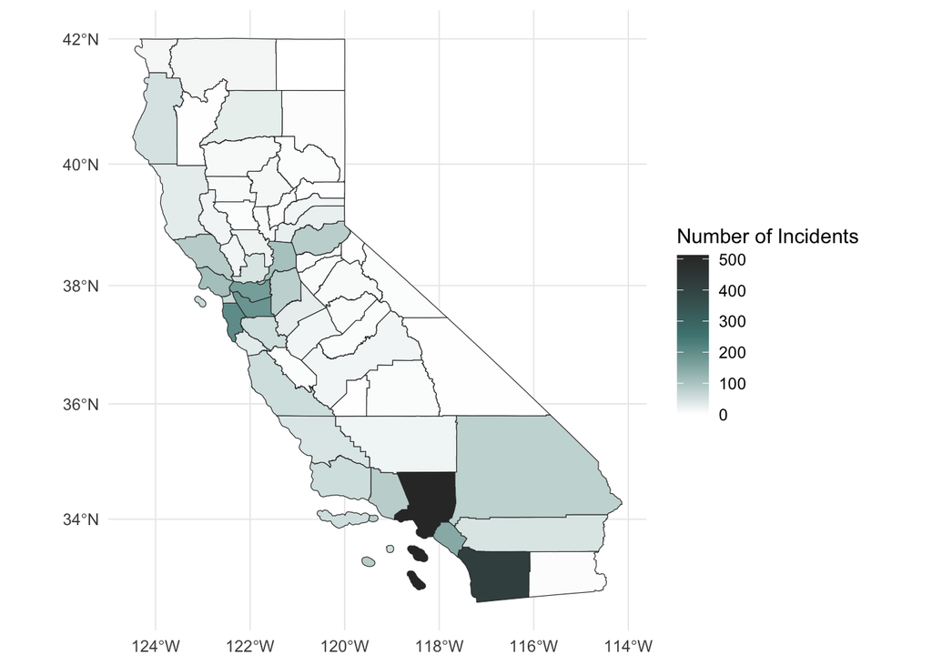

```r
# making the choropeleth
ggplot(data = oil_counts_sf) +
  geom_sf(aes(fill = n_records), color = "grey20", size = 0.1) +
  scale_fill_gradientn(colors = c("white", "#4c8481", "grey20")) +
  labs(fill = "Number of Incidents") +
  theme_minimal() +
  theme(

  )
```

**Figure 2:** A map that shows oil spill incidents across California in 2008, by county. A darker green colored counties indicates a high occurance of oil spill incidents.